# Yewno-Quantitative Analyst Question 3

Leo Guoyuan Liu

May 21, 2018

### **Question 3**

1. Suggest one data source that might be useful to explain or predict the FX market.
2. Derive and discuss relevant analytics from this data source.
3. Determine whether your proposed analytics are co-integrated with currency pairs.
4. Describe and implement a pairs trading strategy exploiting your analytics.
5. Research shows that government bond yield data can be used to explain the FX market.[1]. In this problem, I use U.S. and German government bonds to predict EUR/USD FX pair. According to the uncovered interest rate parity under non arbitrage, the following equation holds.
   $$\frac{ E(S_t)}{S_0} =\frac{1+r_l}{1+r_f}$$
   or approximately
   $$\Delta E(S_t/S_0) =\Delta r_l -\Delta r_f$$

where $E_t(S_t)$ is the expected future spot exchange rate priced by local currency  
USD at time $t$, here EUR/USD pair. $r_l\,r_f$ are the local and foreign currency interest rate.  
The uncovered interest rate parity may not hold for long term. In reality, the uncovered interest parity may not hold for long term. Carry trade is profit on average, the currency with the higher interest rate tends to appreciate (A.P.Chabound 2003).

Since the government bonds good proxy for interest rate. Base on Natalja Lace 2015, I choose 2 year and 10 year government debt yields from US and German specifically. We can expect that the movement of $\Delta S_t$ is linear combination of bond yield.
$$\Delta S_t = \beta_l\Delta y_l+\beta_f \Delta y_f + c$$

```r
read_dat<-function(file,new_name, name="Price"){
data<-read_csv(file)%>%
   mutate(Date=as.Date(Date, format="%B %d, %Y"))%>%
   select(Date, !!new_name:=name)%>%
   to_xts
}




yu2<-read_dat("United States 2-Year Bond Yield Historical Data.csv","US2y")%>% diff
yu10<-read_dat("United States 10-Year Bond Yield Historical Data.csv","US10y")%>% diff
yg2<-read_dat("Germany 2-Year Bond Yield Historical Data.csv","GE2y")%>% diff
yg10<-read_dat("Germany 10-Year Bond Yield Historical Data.csv","GE10y")%>% diff
fx0<-read_dat("EUR_USD Historical Data.csv","FX")
fx<-read_csv("EUR_USD Historical Data.csv")%>%
mutate(Date=as.Date(Date, format="%B %d, %Y"))%>%
mutate(dFX=as.numeric(substr(`Change %`,0,nchar(`Change %`)-1)))%>%
select(Date, dFX)%>%
to_xts


dat<-merge(fx,yu2,yu10,yg2,yg10)
fit<-lm(formula = dFX~., data = dat)
summary(fit)
```

```
Call:
lm(formula = dFX ~ ., data = dat)

Residuals:
     Min       1Q   Median       3Q      Max
-2.55606 -0.29417  0.00618  0.26996  1.86809

Coefficients:
            Estimate Std. Error t value Pr(>|t|)
(Intercept)  0.03231    0.01795   1.800 0.072306 .
US2y        -4.33126    1.15239  -3.759 0.000187 ***
US10y       -2.20184    0.85811  -2.566 0.010527 *
GE2y         7.83004    1.27905   6.122 1.66e-09 ***
GE10y        1.80757    0.81212   2.226 0.026395 *
---
Signif. codes:  0 '***' 0.001 '**' 0.01 '*' 0.05 '.' 0.1 ' ' 1

Residual standard error: 0.4431 on 611 degrees of freedom
  (162 observations deleted due to missingness)
Multiple R-squared:  0.1644,    Adjusted R-squared:  0.159
F-statistic: 30.06 on 4 and 611 DF,  p-value: < 2.2e-16
```

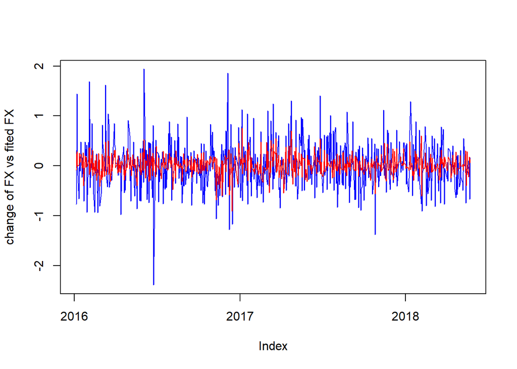

```r
dates=as.Date(names(fit$fitted.values),"%Y-%m-%d")
y=xts(fit$model$dFX, order.by=dates)
y_fit=xts(fit$fitted.values, order.by=dates)
plot(as.zoo(merge(y,y_fit)), ylab="change of FX vs fited FX", col=c("blue","red"),screens=1)
```

3. The hypothesis is that the change of EUR/USD rate might well be cointegrated within government bond yields, and thus lead to a potential mean-reverting systematic trading strategy. The Augmented Dickey-Fuller Test analysis shows that the residual is stationary and there is sufficient evidence to reject the null hypothesis of no cointegrating relationship.

```r
library(tseries)
adf.test(fit$residuals, k=1)
```

```
    Augmented Dickey-Fuller Test

data:  fit$residuals
Dickey-Fuller = -18.933, Lag order = 1, p-value = 0.01
alternative hypothesis: stationary
```

4. Bollinger Band is used to generate tradeable signals with mean-reverting spread from combination of change of exchange rate and bond yields.
   $$x=\Delta S_t - \beta_l\Delta y_l-\beta_f \Delta y_f - c$$

By definition a mean-reverting series will occasionally deviate from its mean and then eventually revert. Bollinger Bands provide a mechanism for entering and exiting trades by employing standard deviation “thresholds” at which trades can be entered into and exited from. To generate trades the first task is to calculate a z-score (also known as a standard score) of the current latest spread. To calcualte the stdv of the spread, I take a rolling window of 30. The z-score is calculated as follows.
$$z=\frac{x -\bar x}{s_x}$$

$$z<-z_{entry}\text{ : Long foreign currency}$$

To calculate the $z$ score,we assign a rolling window of 30 *window =30*.

```r
dat1<-merge(fx0,dat)

Run_Strategy<-function(dat1, fit){
  n=nrow(dat)
  window=30

  # calculate the z score
  dat1<-dat1%>%to_tbl%>%
    mutate(i=row_number(),z=dFX-predict(fit,slice(.,i)))%>%
    mutate(s=rollapply(z,width=window,FUN=sd,align = "right", fill = NA, na.rm = T))%>%
    mutate(m=rollapply(z,width=window,FUN=mean,align = "right", fill = NA, na.rm = T))%>%
    mutate(z=(z-m/s),eur=0,usd=1,value=1)%>%select(Date, FX,z,eur,usd,value)%>% na.omit

  #implement the strategy
  for(i in 2:nrow(dat1)){
      # buy euro if z<-0.5
    if( dat1[i-1,]$usd>0 && dat1[i,]$z< -0.5){
        dat1[i,]$eur=dat1[i-1,]$usd/dat1[i,]$FX
        dat1[i,]$usd=0
        dat1[i,]$value=dat1[i-1,]$usd
        # sell euro if z>0.5
      } else if(dat1[i-1,]$eur>0 && dat1[i,]$z>0.5){
        dat1[i,]$usd=dat1[i-1,]$eur*dat1[i,]$FX
        dat1[i,]$eur=0
        dat1[i,]$value=dat1[i,]$usd
      }else{
        dat1[i,]$usd=dat1[i-1,]$usd
        dat1[i,]$eur=dat1[i-1,]$eur
        dat1[i,]$value=dat1[i,]$usd+dat1[i,]$eur*dat1[i,]$FX
    }
  }

  dat1<-dat1%>%mutate(Return=value/lag(value)-1)
  dat1%>%to_xts

}

result<-Run_Strategy(dat1,fit)
library(PerformanceAnalytics)
performance<-function(r){
  c(
  Return=Return.cumulative(r),
  Sharpe=SharpeRatio(r,FUN="StdDev"),
  VaR=VaR(r,method="historical")
)
}
performance(result$Return)
```

```
      Return       Sharpe          VaR
 0.144540128  0.065379607 -0.005768226
```